# Analyzing trials - Workshop 1

Daniel Hammarström

2 11 2021

## Interpreting the linear model

- A regression model can be used to assess the differences between treatments in a randomized controlled trial (RCT).
- In the simple case, this can be a comparison of change-scores

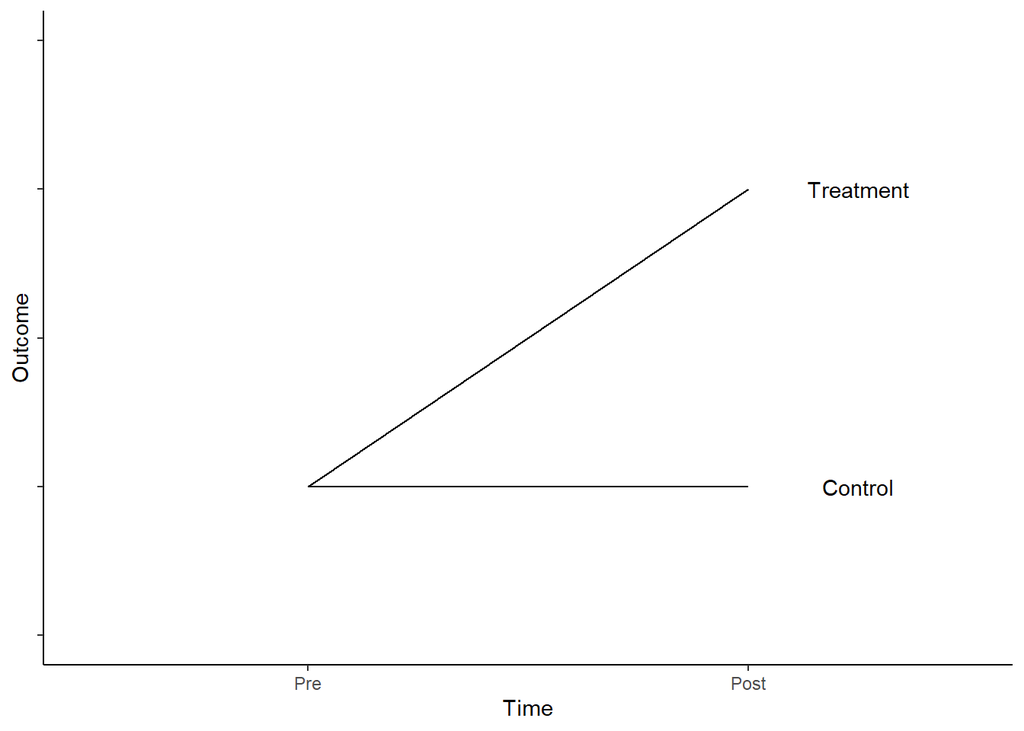

- The alternative hypothesis is that the two groups are different in terms of change scores.

$$\Delta Y_{Treatment}-\Delta Y_{Control} \neq 0$$

- The null-hypothesis that we use in our statistical models is

$$\Delta Y_{Treatment}-\Delta Y_{Control} = 0$$

- In the simple case, this equals a *t*-test.

`t.test(delta ~ group, paired = FALSE)`

- A similar scenario is a comparison between two treatments

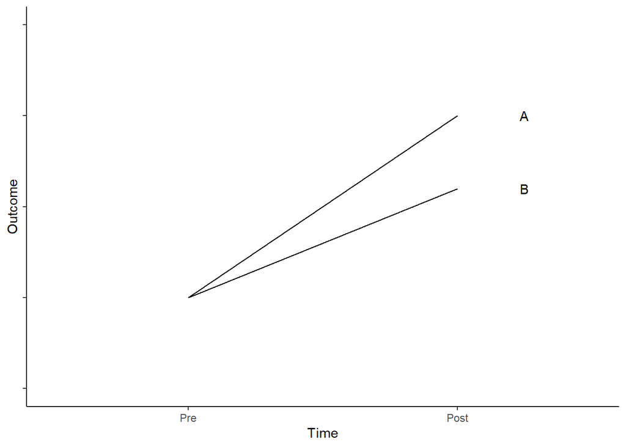

$$\Delta Y_{A}-\Delta Y_{B} = 0$$

- The `tenthirty` data set has similar data as in the above scenario
- We want to know what treatment to recommend for 1RM improvements.

## Ten-thirty: Exercises

- Using the `tenthirty` data, use filter to keep time-point “pre” and “post” for the leg-press exercise.
- Make a plot of the averages of each group.
- Calculate a change score as `post` - `pre`.
- Make a plot of the average change score for each group.
- Fit a regression model (`change ~ group`) and interpret the results.

### Questions:

1. Concerning the sample: Which group has the largest improvement i leg-press 1RM?
2. Concerning inference to the population: Which method do you recommend for improving 1RM leg-press?

### Solutions

Create a plot of averages over time:

```r
library(tidyverse); library(exscidata)
data("tenthirty")

# Save the data set in a filtered version
tenthirty_reduced <- tenthirty %>%
  filter(time %in% c("pre", "post"),
         exercise == "legpress",
         !is.na(load)) %>%
  print()
```

```
## # A tibble: 51 x 5
##    participant time  group exercise  load
##          <dbl> <chr> <chr> <chr>    <dbl>
##  1           1 pre   RM30  legpress   180
##  2           2 pre   RM30  legpress   200
##  3           3 pre   RM30  legpress   330
##  4           4 pre   RM10  legpress   350
##  5           5 pre   RM10  legpress   370
##  6           6 pre   RM30  legpress   400
##  7           7 pre   RM30  legpress   250
##  8           8 pre   RM10  legpress   175
##  9           9 pre   RM10  legpress   270
## 10          10 pre   RM30  legpress   240
## # ... with 41 more rows
```

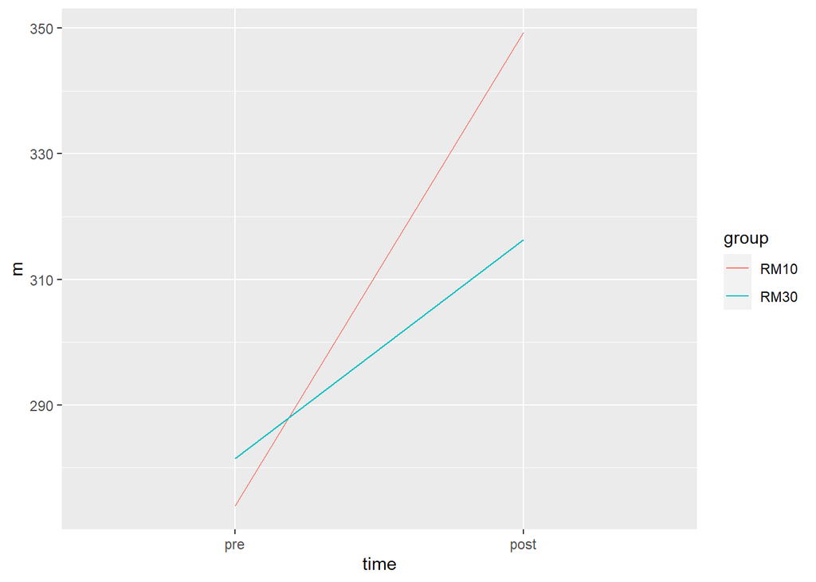

```r
# Create a line plot with one line per group
tenthirty_reduced %>%
  group_by(time, group) %>%
  summarise(m = mean(load)) %>%
  mutate(time = factor(time, levels = c("pre", "post"))) %>%
  ggplot(aes(time, m, color = group,
             group = group)) + geom_line()
```

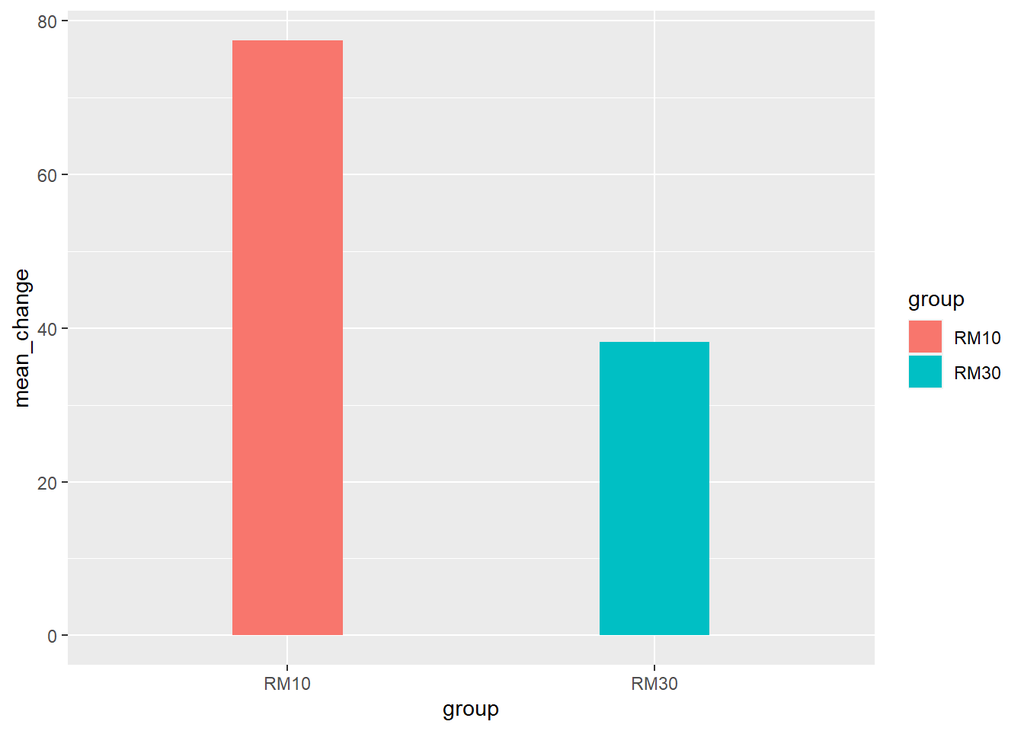

```r
# Create a plot of average changes per group
tenthirty_reduced %>%
  pivot_wider(names_from = time,
              values_from = load) %>%
  mutate(change = post - pre) %>%
  group_by(group) %>%
  summarise(mean_change = mean(change, na.rm = TRUE)) %>%
  ggplot(aes(group, mean_change, fill = group)) +
  geom_bar(stat = "identity", width = 0.3)
```

```r
# Calculate the average change per group, and difference between groups
tenthirty_reduced %>%
  pivot_wider(names_from = time,
              values_from = load) %>%
  mutate(change = post - pre) %>%
  group_by(group) %>%
  summarise(mean_change = mean(change, na.rm = TRUE)) %>%
  pivot_wider(names_from = group,
              values_from = mean_change) %>%
  mutate(diff = RM30 - RM10) %>%
  print()
```

```
## # A tibble: 1 x 3
##    RM10  RM30  diff
##   <dbl> <dbl> <dbl>
## 1  77.4  38.2 -39.2
```

```r
# Calculate change score and save new data set
dat <- tenthirty_reduced %>%
  pivot_wider(names_from = time,
              values_from = load) %>%
  mutate(change = post - pre) %>%
  print()
```

```
## # A tibble: 27 x 6
##    participant group exercise   pre  post change
##          <dbl> <chr> <chr>    <dbl> <dbl>  <dbl>
##  1           1 RM30  legpress   180  200     20
##  2           2 RM30  legpress   200  225     25
##  3           3 RM30  legpress   330   NA     NA
##  4           4 RM10  legpress   350  481.   131.
##  5           5 RM10  legpress   370  500    130
##  6           6 RM30  legpress   400  440     40
##  7           7 RM30  legpress   250  300     50
##  8           8 RM10  legpress   175  210     35
##  9           9 RM10  legpress   270  290     20
## 10          10 RM30  legpress   240  255     15
## # ... with 17 more rows
```

```r
# Fit model with change scores explained by group
m1 <- lm(change ~ group, data = dat)

#
summary(m1)
```

```
##
## Call:
## lm(formula = change ~ group, data = dat)
##
## Residuals:
##     Min      1Q  Median      3Q     Max
## -72.404 -19.432  -7.793  12.013  87.596
##
## Coefficients:
##             Estimate Std. Error t value Pr(>|t|)
## (Intercept)    77.40      11.34   6.826  7.4e-07 ***
## groupRM30     -39.22      16.75  -2.342   0.0287 *
## ---
## Signif. codes:  0 '***' 0.001 '**' 0.01 '*' 0.05 '.' 0.1 ' ' 1
##
## Residual standard error: 40.89 on 22 degrees of freedom
##   (3 observations deleted due to missingness)
## Multiple R-squared:  0.1995, Adjusted R-squared:  0.1631
## F-statistic: 5.483 on 1 and 22 DF,  p-value: 0.02866
```

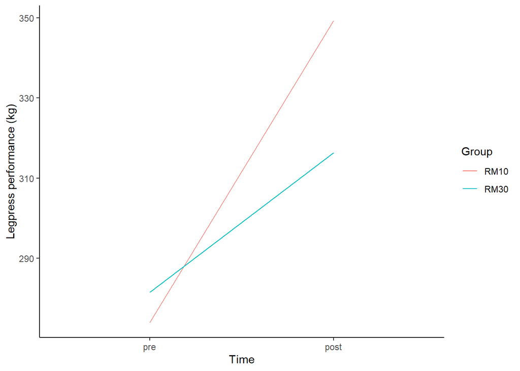

Group averages over time

```r
library(exscidata)

tenthirty %>%
  filter(exercise == "legpress",
         time %in% c("pre", "post")) %>%
  mutate(time = factor(time, levels = c("pre", "post"))) %>%
  group_by(time, group) %>%
  summarise(m = mean(load, na.rm = TRUE)) %>%
  ggplot(aes(time, m, group = group, color = group)) + geom_line() +
  labs(x = "Time", y = "Legpress performance (kg)", color = "Group") +
          theme_classic()
```

## From t-test to ANCOVA

- Above we used the simple comparison of change score. A more appropriate model to study outcomes of a RCT is an analysis of co-variance (ANCOVA)
- In an ANCOVA change-scores or post values are compared and the estimates tells you the adjusted differences between groups if they had the exact same starting point.

### ANCOVA exercise

- Fit an ANCOVA model with change scores as the dependent variable
- Fit an ANCOVA model with the post values as the dependent variable
- Pre-training values and group should be covariates in both models.

### Questions

1. Concerning inference to the population: Which method do you recommend for improving 1RM leg-press?
2. In what ways are the models different?

### Soultions

```r
# Create a data set with change

dat <- tenthirty %>%
  filter(exercise == "legpress",
         time %in% c("pre", "post")) %>%
  pivot_wider(names_from = time,
              values_from = load) %>%
  mutate(change = post - pre,
         pre = pre - mean(pre)) %>% # Mean center pre-values
  print()
```

```
## # A tibble: 27 x 6
##    participant group exercise     pre  post change
##          <dbl> <chr> <chr>      <dbl> <dbl>  <dbl>
##  1           1 RM30  legpress  -97.6   200     20
##  2           2 RM30  legpress  -77.6   225     25
##  3           3 RM30  legpress   52.4    NA     NA
##  4           4 RM10  legpress   72.4   481.   131.
##  5           5 RM10  legpress   92.4   500    130
##  6           6 RM30  legpress  122.    440     40
##  7           7 RM30  legpress  -27.6   300     50
##  8           8 RM10  legpress -103.    210     35
##  9           9 RM10  legpress   -7.59  290     20
## 10          10 RM30  legpress  -37.6   255     15
## # ... with 17 more rows
```

```r
# Fit models

m1 <- lm(post ~ pre + group, data = dat)

m2 <- lm(change ~ pre + group, data = dat)


summary(m1)
```

```
##
## Call:
## lm(formula = post ~ pre + group, data = dat)
##
## Residuals:
##     Min      1Q  Median      3Q     Max
## -69.429 -23.565   1.562  19.278  75.601
##
## Coefficients:
##             Estimate Std. Error t value Pr(>|t|)
## (Intercept) 356.4110    10.7143  33.265  < 2e-16 ***
## pre           1.2495     0.1287   9.709 3.24e-09 ***
## groupRM30   -40.7836    15.8098  -2.580   0.0175 *
## ---
## Signif. codes:  0 '***' 0.001 '**' 0.01 '*' 0.05 '.' 0.1 ' ' 1
##
## Residual standard error: 38.54 on 21 degrees of freedom
##   (3 observations deleted due to missingness)
## Multiple R-squared:  0.8245, Adjusted R-squared:  0.8077
## F-statistic: 49.31 on 2 and 21 DF,  p-value: 1.164e-08
```

```r
summary(m2)
```

```
##
## Call:
## lm(formula = change ~ pre + group, data = dat)
##
## Residuals:
##     Min      1Q  Median      3Q     Max
## -69.429 -23.565   1.562  19.278  75.601
##
## Coefficients:
##             Estimate Std. Error t value Pr(>|t|)
## (Intercept)  78.8184    10.7143   7.356 3.08e-07 ***
## pre           0.2495     0.1287   1.939   0.0661 .
## groupRM30   -40.7836    15.8098  -2.580   0.0175 *
## ---
## Signif. codes:  0 '***' 0.001 '**' 0.01 '*' 0.05 '.' 0.1 ' ' 1
##
## Residual standard error: 38.54 on 21 degrees of freedom
##   (3 observations deleted due to missingness)
## Multiple R-squared:  0.321,  Adjusted R-squared:  0.2564
## F-statistic: 4.965 on 2 and 21 DF,  p-value: 0.01715
```

```r
m3 <- aov(post ~ pre + group, data = dat)

summary(m3)
```

```
##             Df Sum Sq Mean Sq F value   Pr(>F)
## pre          1 136621  136621  91.974 4.01e-09 ***
## group        1   9885    9885   6.655   0.0175 *
## Residuals   21  31194    1485
## ---
## Signif. codes:  0 '***' 0.001 '**' 0.01 '*' 0.05 '.' 0.1 ' ' 1
## 3 observations deleted due to missingness
```

```r
anova(m1)
```

```
## Analysis of Variance Table
##
## Response: post
##           Df Sum Sq Mean Sq F value   Pr(>F)
## pre        1 136621  136621 91.9741 4.01e-09 ***
## group      1   9885    9885  6.6545  0.01748 *
## Residuals 21  31194    1485
## ---
## Signif. codes:  0 '***' 0.001 '**' 0.01 '*' 0.05 '.' 0.1 ' ' 1
```

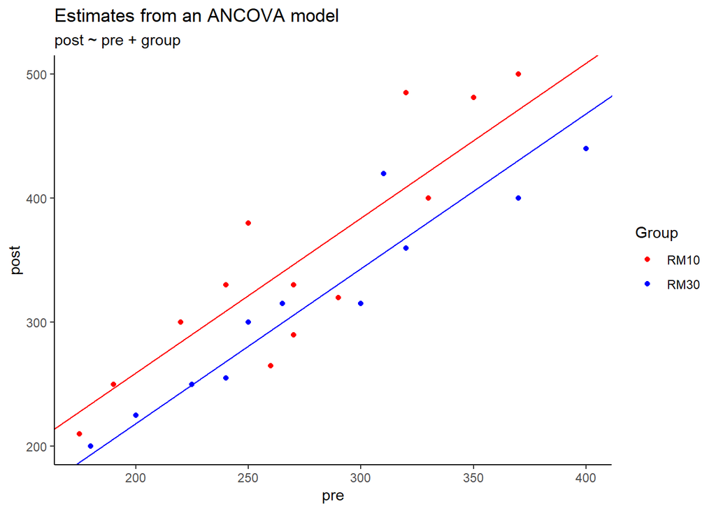

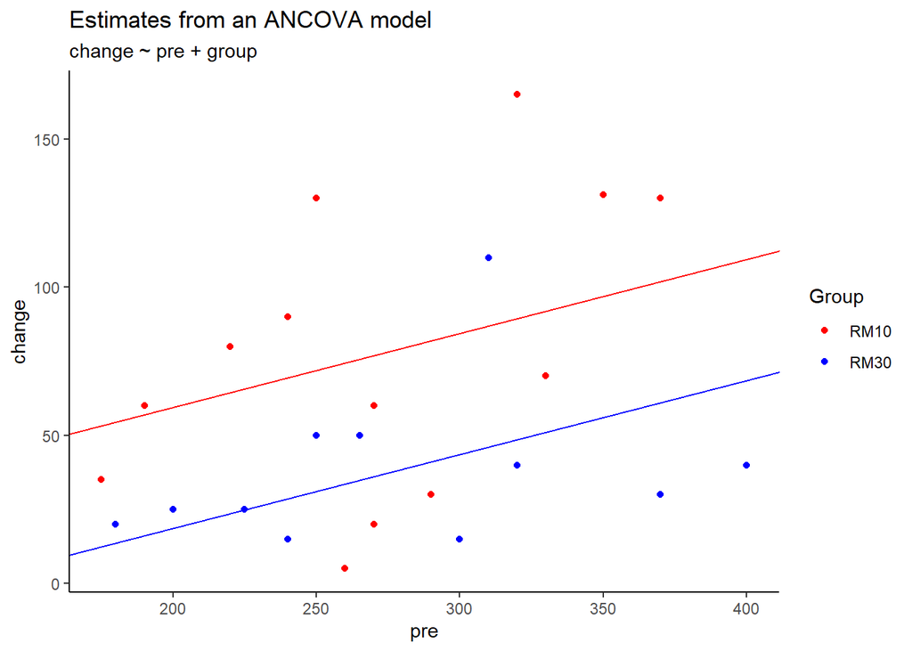

## Hypertrophy and graded protein dose

- Read Haun et al. and find the main purpose/aim/hypothesis of the study.
- How do they motivate their purpose/aim/hypothesis?
- What is the statistical test used test the main hypotheses?

## Make it simple!

Design an analysis of the data from Haun et al.: - include only two time-points (T1 and T3) - Select one meassure of muscle hypertrophy - Select a test for a null-hypothesis significance test - Do your results correspond to what is found in Haun et al.?